# Подготовка медицинских данных для анализа. Построение и анализ ROC-кривой

Oksana Plastinina

Ноябрь 2025

```r
library(readxl)
library(tidyverse)
library(stringr)
library(flextable)
library(pROC)
library(ggplot2)
```

```r
trauma_row <- read_excel('trauma.xlsx')
```

В работе использовался полностью сгенерированный учебный датасет «trauma.xlsx», содержащий данные пациентов, госпитализированных в больницу после получения черепно-мозговой травмы вследствие падения с электросамоката.

Предоставленый файл «trauma.xlsx», который содержит следующие данные:

- **id** – номер пациента в списке
- **Name** – имя фамилия пациента
- **Sex** – пол пациента
- **Age** – возраст пациента (лет)
- **Height** – рост пациента (дюймы1)
- **Weight** – масса тела пациента (фунты2)
- **SBP** – систолическое артериальное давление при поступлении (мм рт.ст.)
- **DBP** – диастолическое артериальное давление при поступлении (мм рт.ст.)
- **FOUR** – балл по шкале комы FOUR при поступлении
- **GSC** – балл по шкале комы Глазго при поступлении
- **Hb** – уровень гемоглобина при поступлении (г/дл)
- **Death** – летальный исход в течение 24 часов (1 – наступил, 0 – нет)

## **Очистка базы данных**

### **Анализ значений переменных исходной базы данных**

```r
#проводим первичный анализ
cat('Статистика по всем переменных исходной базы данных\n')
```

```
## Статистика по всем переменных исходной базы данных
```

```r
summary(trauma_row)
```

```
##        id             Name               Sex                 Age
##  Min.   :   1.0   Length:1024        Length:1024        Min.   :18.00
##  1st Qu.: 256.8   Class :character   Class :character   1st Qu.:29.00
##  Median : 512.5   Mode  :character   Mode  :character   Median :41.00
##  Mean   : 512.5                                         Mean   :40.94
##  3rd Qu.: 768.2                                         3rd Qu.:53.00
##  Max.   :1024.0                                         Max.   :64.00
##     Height              Weight           SBP             DBP
##  Length:1024        Min.   :133.3   Min.   : 90.0   Min.   : 58.00
##  Class :character   1st Qu.:181.7   1st Qu.:106.0   1st Qu.: 78.00
##  Mode  :character   Median :193.9   Median :110.0   Median : 84.00
##                     Mean   :193.5   Mean   :110.8   Mean   : 84.78
##                     3rd Qu.:205.4   3rd Qu.:116.0   3rd Qu.: 90.00
##                     Max.   :253.1   Max.   :134.0   Max.   :110.00
##       FOUR             GSC               Hb           Death
##  Min.   : 0.000   Min.   : 3.000   Min.   : 0.0   Min.   :0.0000
##  1st Qu.: 7.000   1st Qu.: 6.000   1st Qu.:12.0   1st Qu.:0.0000
##  Median : 9.000   Median : 8.000   Median :13.1   Median :0.0000
##  Mean   : 8.853   Mean   : 7.785   Mean   :12.8   Mean   :0.3994
##  3rd Qu.:11.000   3rd Qu.:10.000   3rd Qu.:14.0   3rd Qu.:1.0000
##  Max.   :16.000   Max.   :14.000   Max.   :16.2   Max.   :1.0000
```

```r
cat('\nТипы всех переменных исходной базы данных\n')
```

```
##
## Типы всех переменных исходной базы данных
```

```r
str(trauma_row)
```

```
## tibble [1,024 × 12] (S3: tbl_df/tbl/data.frame)
##  $ id    : num [1:1024] 1 2 3 4 5 6 7 8 9 10 ...
##  $ Name  : chr [1:1024] "Jecelle Oberly" "Halie Mccone" "Kole Cook" "Patricia Davis" ...
##  $ Sex   : chr [1:1024] "Female" "Female" "Male" "Female" ...
##  $ Age   : num [1:1024] 24 35 39 20 63 60 63 26 20 25 ...
##  $ Height: chr [1:1024] "68\"" "69.8\"" "72.8\"" "70.5\"" ...
##  $ Weight: num [1:1024] 176 184 210 195 169 ...
##  $ SBP   : num [1:1024] 102 116 122 120 112 118 122 114 104 106 ...
##  $ DBP   : num [1:1024] 78 86 102 100 84 88 100 94 84 78 ...
##  $ FOUR  : num [1:1024] 10 9 12 11 9 13 10 11 10 7 ...
##  $ GSC   : num [1:1024] 8 7 12 9 7 11 9 10 9 5 ...
##  $ Hb    : num [1:1024] 11.4 12.2 15 12.2 12.4 15 11.8 14.4 11.4 12.2 ...
##  $ Death : num [1:1024] 1 0 0 0 1 0 0 0 0 1 ...
```

```r
cat('\nАнализ разности САД и ДАД\n')
```

```
##
## Анализ разности САД и ДАД
```

```r
trauma_row %>%
  mutate(
    dif = SBP - DBP
  ) %>%
  select(dif) %>%
  summary()
```

```
##       dif
##  Min.   :20.00
##  1st Qu.:22.00
##  Median :26.00
##  Mean   :25.99
##  3rd Qu.:30.00
##  Max.   :32.00
```

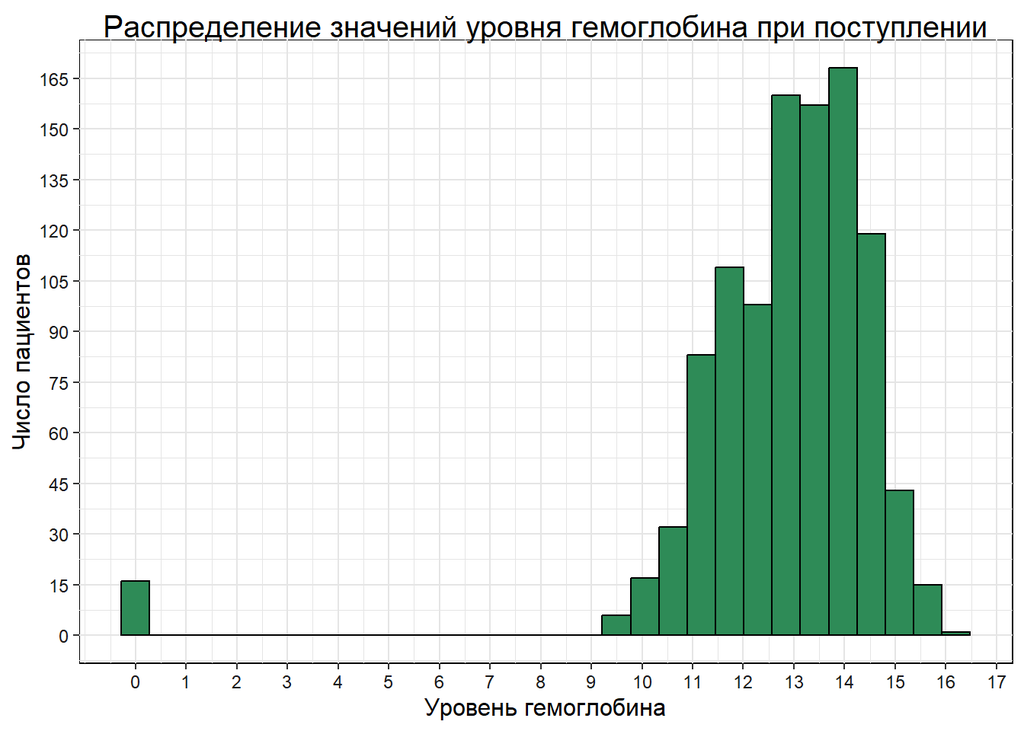

```r
trauma_row %>%
  ggplot() +
  geom_histogram(aes(x = Hb), fill = 'seagreen', colour = 'black')+
  labs(
    title = 'Распределение значений уровня гемоглобина при поступлении',
    x = 'Уровень гемоглобина',
    y = 'Число пациентов'
  )+
  scale_x_continuous(breaks = seq(0,18, 1))+
  scale_y_continuous(breaks = seq(0,170, 15))
```

Значение уровня гемоглобина при поступлении иммет минимальный показатель 0, что не явяляется возможным. Для того, чтобы определить, как распределены значения данного признака в исходных данных построим гистограмму. Из графика видно, что примерно 20 значений соответсвуют 0. Остальные значения больше 9 и меньше 17, что соответсвует возможным значениям.

В типах данных есть ошибки внесения переменной Height из-за чего она определяестя как текстовая переменная. Также Death лучше скорее рассматривать как фактор.

Значения остальных переменных рассматриваем как возможные.

### **Подготовка базы данных для работы**

```r
#Чистка данных

trauma <- trauma_row %>%
  mutate(
    Hb = case_when(Hb == '0' ~ NA,
                   TRUE ~ Hb),
    Death = as.factor(Death),
    Height = as.numeric(str_remove_all(Height, '"')),
    Heightm = round((Height*2.54)/100,2),
    Weightkg = round(Weight/2.2,1)
  )

cat('Статистика по всем переменных базы данных для дальнейшей работы\n')
```

```
## Статистика по всем переменных базы данных для дальнейшей работы
```

```r
summary(trauma)
```

```
##        id             Name               Sex                 Age
##  Min.   :   1.0   Length:1024        Length:1024        Min.   :18.00
##  1st Qu.: 256.8   Class :character   Class :character   1st Qu.:29.00
##  Median : 512.5   Mode  :character   Mode  :character   Median :41.00
##  Mean   : 512.5                                         Mean   :40.94
##  3rd Qu.: 768.2                                         3rd Qu.:53.00
##  Max.   :1024.0                                         Max.   :64.00
##
##      Height          Weight           SBP             DBP
##  Min.   :63.80   Min.   :133.3   Min.   : 90.0   Min.   : 58.00
##  1st Qu.:69.70   1st Qu.:181.7   1st Qu.:106.0   1st Qu.: 78.00
##  Median :72.80   Median :193.9   Median :110.0   Median : 84.00
##  Mean   :72.42   Mean   :193.5   Mean   :110.8   Mean   : 84.78
##  3rd Qu.:75.10   3rd Qu.:205.4   3rd Qu.:116.0   3rd Qu.: 90.00
##  Max.   :79.90   Max.   :253.1   Max.   :134.0   Max.   :110.00
##
##       FOUR             GSC               Hb        Death      Heightm
##  Min.   : 0.000   Min.   : 3.000   Min.   : 9.40   0:615   Min.   :1.62
##  1st Qu.: 7.000   1st Qu.: 6.000   1st Qu.:12.10   1:409   1st Qu.:1.77
##  Median : 9.000   Median : 8.000   Median :13.10           Median :1.85
##  Mean   : 8.853   Mean   : 7.785   Mean   :13.01           Mean   :1.84
##  3rd Qu.:11.000   3rd Qu.:10.000   3rd Qu.:14.00           3rd Qu.:1.91
##  Max.   :16.000   Max.   :14.000   Max.   :16.20           Max.   :2.03
##                                    NA's   :16
##     Weightkg
##  Min.   : 60.60
##  1st Qu.: 82.58
##  Median : 88.10
##  Mean   : 87.97
##  3rd Qu.: 93.40
##  Max.   :115.00
##
```

Значения гемоглобина у пациентов заменили на пропуски. Сделали переменную Death фактором. Исправили ошибки внесения переменной Height и сделелали ее числовой. Создали переменные Heightm и Weightkg, соответствующие росту в м и массе в кг.

## **Анализ данных. Описательная статистика**

### **Анализ качественных переменных**

```r
#статистика для пола по группам исхода

sexcount <- trauma %>%
  group_by(Death, Sex) %>%
  summarise(
    'Количество пациентов и их % от общего числа' = paste0 (n(), ' (', round(n()/nrow(trauma),3) * 100, '%)' ),
  .groups = 'drop'
  ) %>%
  bind_rows(
    trauma %>%
  group_by(Death) %>%
  summarise(
    'Sex' = 'Всего с таким исходом',
    'Количество пациентов и их % от общего числа' = paste0 (n(), ' (', round(n()/nrow(trauma),3) * 100, '%)' ),
  .groups = 'drop'
  )) %>%
  arrange(Death, Sex) %>%
  mutate(
    Sex = case_when(
      Sex == 'Male' ~ 'Мужчина',
      Sex == 'Female' ~ 'Женщина',
      TRUE ~ Sex
    ),
    Death = recode(Death, '0' = 'не наступил летальный исход в течение 24 часов', '1' = 'наступил летальный исход в течение 24 часов')
  ) %>%
  rename('Исход' = Death, 'Пол' = Sex) %>%
  as_grouped_data(groups = 'Исход')

coomment2 <- paste0(
  'Всего пациентов в исследовании ',
  nrow(trauma),
  '. \nИз них ',
  sum(trauma$Sex == 'Female'),
  ' (',
  round(sum(trauma$Sex == 'Female')/nrow(trauma),3) * 100,
  '%) пациентов - женщины, ',
  sum(trauma$Sex == 'Male'),
  ' (',
  round(sum(trauma$Sex == 'Male')/nrow(trauma),3) * 100,
  '%) - мужчины.'
)

#визуализация
sexcount %>%
  as_flextable() %>%
  theme_box() %>%
  bg(part = "header", bg = "aquamarine") %>%
  bg(i = ~ !is.na(Исход), bg = "grey90", part = "body") %>%
  align(part = 'all', align = 'center') %>%
  set_table_properties(layout = 'autofit', width = 0.8) %>%
  add_footer_lines(coomment2) %>%
  set_caption('Таблица 1 - Описательные статистики качественных признаков')
```

Таблица 1 - Описательные статистики качественных признаков

| Пол | Количество пациентов и их % от общего числа |
| --- | --- |
| Исход: не наступил летальный исход в течение 24 часов |  |
| Женщина | 226 (22.1%) |
| Мужчина | 389 (38%) |
| Всего с таким исходом | 615 (60.1%) |
| Исход: наступил летальный исход в течение 24 часов |  |
| Женщина | 158 (15.4%) |
| Мужчина | 251 (24.5%) |
| Всего с таким исходом | 409 (39.9%) |

Всего пациентов в исследовании 1024. Из них 384 (37.5%) пациентов - женщины, 640 (62.5%) - мужчины.

### **Анализ количественных переменных**

Сразу введем в базу данных переменную ИМТ для оценки параметров массы и роста

```r
trauma <- trauma %>%
  mutate(
    BMI = round(Weightkg/(Heightm^2), 1)
  )
```

```r
#сосздаем лист со статистикой для количественных признаков
statistic <- list(
  'Количество NA' = ~sum(is.na(.x)) %>% as.character(),
  'Количество \nнаблюдений' = ~sum(!is.na(.x)) %>% as.character(),
  'Среднее' = ~round(mean(.x, na.rm = T), 1) %>% as.character(),
  'Медиана' = ~median(.x, na.rm = T) %>% as.character(),
  'Стандатрное \nотклонение' = ~sd(.x, na.rm = T) %>% round(2) %>% as.character(),
  '25-75 квартили' = ~paste0(quantile(.x, .25, na.rm = TRUE), ' - ', quantile(.x, .75, na.rm = TRUE)),
  'Мин-макс \nзначение' = ~paste0(min(.x, na.rm = T), ' - ', max(.x, na.rm = T)) %>% as.character()
  )
```

```r
#создаем дата фрейм со статистикой
statistic_traumaDeath <- trauma %>%
  group_by(Death) %>%
  summarise(
    across(where(is.numeric) & !c('id', 'Height', 'Weight'), statistic)
    ) %>%
  pivot_longer(!Death, names_to = c('Variable', 'Statustic'), names_sep = '_', values_to = 'Value') %>%
  pivot_wider(names_from = 'Variable', values_from = 'Value') %>%
  mutate(
  Death = recode(Death, '0' = 'не наступил летальный исход в течение 24 часов', '1' = 'наступил летальный исход в течение 24 часов'))%>%
  rename('Исход' = Death ) %>%
  as_grouped_data(groups = 'Исход')

comments <- 'САД - систолическое артериальное давление при поступлении; \nДАД - диастолическое артериальное давление при поступлении; \nFOUR – балл по шкале комы FOUR при поступлении; \nGSC – балл по шкале комы Глазго при поступлении; \nHb – уровень гемоглобина при поступлении.'


#Визуализируем статистику с помощью flextable
as_flextable(statistic_traumaDeath) %>%
  theme_box() %>%
  bg(part = "header", bg = "aquamarine") %>%
  bg(i = ~ !is.na(Исход), bg = "grey90", part = "body") %>%
  align(part = 'all', align = 'center') %>%
  set_header_labels(Statustic = 'Параметр', Age = 'Возраст, \nгод', SBP = 'САД, \nмм рт.ст.', DBP = 'ДАД, \nмм рт.ст.', Heightm = 'Рост, м', Weightkg = 'Масса, кг', Hb = 'Hb, г/дл', BMI = 'ИМТ') %>%
  set_table_properties(layout = 'autofit', width = 1) %>%
  set_caption('Таблица 2 - Описательные статистики количественный признаков') %>%
  add_footer_lines(comments)
```

Таблица 2 - Описательные статистики количественный признаков

| Параметр | Возраст, год | САД, мм рт.ст. | ДАД, мм рт.ст. | FOUR | GSC | Hb, г/дл | Рост, м | Масса, кг | ИМТ |
| --- | --- | --- | --- | --- | --- | --- | --- | --- | --- |
| Исход: не наступил летальный исход в течение 24 часов |  |  |  |  |  |  |  |  |  |
| Количество NA | 0 | 0 | 0 | 0 | 0 | 10 | 0 | 0 | 0 |
| Количество наблюдений | 615 | 615 | 615 | 615 | 615 | 605 | 615 | 615 | 615 |
| Среднее | 40.4 | 113.7 | 87.6 | 10.6 | 9.3 | 13.4 | 1.8 | 88.2 | 26.1 |
| Медиана | 40 | 114 | 88 | 10 | 9 | 13.5 | 1.85 | 88.2 | 26 |
| Стандатрное отклонение | 13.64 | 6.74 | 7.81 | 2.21 | 2.07 | 1.19 | 0.08 | 8.5 | 2.59 |
| 25-75 квартили | 29 - 52 | 108 - 118 | 82 - 94 | 9 - 12 | 8 - 11 | 12.5 - 14.3 | 1.78 - 1.91 | 82.85 - 93.55 | 24.3 - 27.75 |
| Мин-макс значение | 18 - 64 | 96 - 134 | 66 - 110 | 3 - 16 | 4 - 14 | 9.4 - 16.2 | 1.62 - 2.01 | 60.6 - 115 | 18.5 - 35 |
| Исход: наступил летальный исход в течение 24 часов |  |  |  |  |  |  |  |  |  |
| Количество NA | 0 | 0 | 0 | 0 | 0 | 6 | 0 | 0 | 0 |
| Количество наблюдений | 409 | 409 | 409 | 409 | 409 | 403 | 409 | 409 | 409 |
| Среднее | 41.7 | 106.3 | 80.5 | 6.2 | 5.5 | 12.4 | 1.8 | 87.7 | 26.1 |
| Медиана | 43 | 106 | 80 | 6 | 5 | 12.7 | 1.85 | 88 | 26 |
| Стандатрное отклонение | 13.68 | 6.19 | 7.43 | 1.99 | 1.77 | 1.2 | 0.08 | 7.97 | 2.58 |
| 25-75 квартили | 30 - 53 | 102 - 110 | 76 - 86 | 5 - 8 | 4 - 7 | 11.45 - 13.3 | 1.76 - 1.9 | 82 - 93.1 | 24.3 - 27.9 |
| Мин-макс значение | 18 - 64 | 90 - 124 | 58 - 102 | 0 - 11 | 3 - 10 | 9.4 - 14.8 | 1.64 - 2.03 | 65.8 - 111.2 | 19.4 - 33 |

САД - систолическое артериальное давление при поступлении; ДАД - диастолическое артериальное давление при поступлении; FOUR – балл по шкале комы FOUR при поступлении; GSC – балл по шкале комы Глазго при поступлении; Hb – уровень гемоглобина при поступлении.

Из таблицы можно сделать следующие выводы: - база данных не содержит пропущенных значений за исключением 16 наблюдений уровня гемоглобина; - количество пациентов исследования с летальным исходом в течение 24 часов меньше; - перменная возраст и ИМТ примерно совпадают в двух группах; - значения САД и ДАД у пациентов без летального исхода несколько выше; - баллы по шкале комы FOUR и Глазго у пациентов без летального исхода выше, что согласуется с концепцией этих тестов; - значения уровня гемоглобина у пациентов без летального исхода несколько выше;

#### **Рассмотрим подробнее пациентов с анемией**

Для определения состояния анемии использовалии следущие референтные значения: Мужчины - 13.5–16 г/дл, Женщины - 12–14 г/дл.

```r
#Статистика по растпростанению анемии

#стичаем количество паиценов с анемией и их %
trauma_anemia <-  trauma %>%
  group_by(Death,Sex) %>%
  summarise(
    n = n(),
    patients_with_anemia = sum(ifelse((Sex == 'Female' & Hb<12) | (Sex == 'Male' & Hb<13.5), 1, 0), na.rm = T),
    .groups = 'drop') %>%
  group_by(Sex) %>%
  mutate(
    '% числа пациентов с анемией  в этой группе среди этого пола' = paste0(round(patients_with_anemia/sum(n)*100), '%')) %>%
  ungroup() %>%
  mutate('% числа пациентов с анемией cреди всех пациентов' = paste0(round(patients_with_anemia/nrow(trauma)*100,1), '%'),
         '% числа пациентов с анемией cреди всех пациентов с анемией' = paste0(round(patients_with_anemia/sum(patients_with_anemia)*100,1), '%')
  ) %>%
  mutate(
  Sex = case_when(
    Sex == 'Male' ~ 'Мужчина',
    Sex == 'Female' ~ 'Женщина',
    TRUE ~ Sex
  )) %>%
  ungroup() %>%
  mutate(Death = recode(Death, '0' = 'не наступил летальный исход в течение 24 часов', '1' = 'наступил летальный исход в течение 24 часов'))%>%
  rename('Исход' = Death ) %>%
  as_grouped_data(groups = 'Исход')

#Формулируем комментарий к таблице
general_anemia <- paste0(
  'Количество пациентов с анемией - ',
  sum(trauma_anemia$patients_with_anemia, na.rm = TRUE),
  ', что составляет ',
  round(sum(trauma_anemia$patients_with_anemia,na.rm = TRUE)/nrow(trauma)*100,1),
  '% от общего числа пациентов. \nРеферентные значения: Мужчины - 13.5–16 г/дл, Женщины - 12–14 г/дл.'
  )

#визуализируем
trauma_anemia %>%
  as_flextable() %>%
  theme_box() %>%
  bg(part = "header", bg = "aquamarine") %>%
  bg(i = ~ !is.na(Исход), bg = "grey90", part = "body") %>%
  align(part = 'all', align = 'center') %>%
  align(part = 'footer', align = 'left') %>%
  set_header_labels(Sex = 'Пол', patients_with_anemia = 'Количество пациентов \nс анемией', n = 'Количество пациентов') %>%
  set_table_properties(layout = 'autofit', width = 1)%>%
  set_caption('Таблица 3 - Количество пациентов с анемией и их соотношения в разных группах') %>%
  add_footer_lines(general_anemia)
```

Таблица 3 - Количество пациентов с анемией и их соотношения в разных группах

| Пол | Количество пациентов | Количество пациентов с анемией | % числа пациентов с анемией в этой группе среди этого пола | % числа пациентов с анемией cреди всех пациентов | % числа пациентов с анемией cреди всех пациентов с анемией |
| --- | --- | --- | --- | --- | --- |
| Исход: не наступил летальный исход в течение 24 часов |  |  |  |  |  |
| Женщина | 226 | 95 | 25% | 9.3% | 20.7% |
| Мужчина | 389 | 71 | 11% | 6.9% | 15.5% |
| Исход: наступил летальный исход в течение 24 часов |  |  |  |  |  |
| Женщина | 158 | 131 | 34% | 12.8% | 28.6% |
| Мужчина | 251 | 161 | 25% | 15.7% | 35.2% |

Количество пациентов с анемией - 458, что составляет 44.7% от общего числа пациентов. Референтные значения: Мужчины - 13.5–16 г/дл, Женщины - 12–14 г/дл.

Анемия в нашем исследовании втречается чаще у женщин, чем у мужчин, 60% и 36% их них имеют сниженный гемоглобин соответственно. Большая половина женщин и мужчин с анемией имели летальный исход в результате ЧМТ в течение 24 ч, 58% и 69% соответственно.

#### **Рассмотрим подробнее пациентов с высоким ИМТ (>30)**

```r
#считаем пациентов с высоким ИМТ и их соотношения относительно разных групп
trauma_BMI <- trauma %>%
  # filter(BMI > 30) %>%
  group_by(Death) %>%
  summarise(
    ngener = n() %>% as.character(),
    nhighbmi = paste0(sum(BMI > 30), ' (', round(sum(BMI>30)/sum(trauma$BMI>30)*100,1), '%)'),
      # sum(BMI > 30) %>% as.character(),
    perhighbmi = paste(round(sum(BMI>30)/n()*100,1), '%')
  ) %>%
  mutate(
  Death = recode(Death, '0' = 'Не наступил', '1' = 'Наступил'))

#визуализируем
trauma_BMI %>%
  flextable() %>%
  theme_box() %>%
  bg(part = "header", bg = "aquamarine") %>%
  align(part = 'all', align = 'center') %>%
 set_header_labels(ngener = 'Количество пациентов', nhighbmi = 'Количество пациентов с высоким ИМТ (% от всех пациентов с высоким ИМТ)', perhighbmi = '% пациентов с высоким ИМТ в этой группе', Death = 'Летальный исход в течение 24 ч') %>%
  set_table_properties(layout = 'autofit', width = 1) %>%
  set_caption('Таблица 4 - Количество пациентов с высоким ИМТ (>30)  и их соотношение в группах с разным исходом')
```

Таблица 4 - Количество пациентов с высоким ИМТ (>30) и их соотношение в группах с разным исходом

| Летальный исход в течение 24 ч | Количество пациентов | Количество пациентов с высоким ИМТ (% от всех пациентов с высоким ИМТ) | % пациентов с высоким ИМТ в этой группе |
| --- | --- | --- | --- |
| Не наступил | 615 | 41 (57.7%) | 6.7 % |
| Наступил | 409 | 30 (42.3%) | 7.3 % |

```r
# trauma_row %>%
#   mutate(
#     Height = as.numeric(str_remove_all(Height, '"')),
#     Heightm = round((Height*2.54)/100,2),
#     Weightkg = round(Weight/2.2,1),
#     BMI = round(Weightkg/(Heightm^2), 1)
#   ) %>%
#   filter(BMI>30) %>%
#   nrow()

# как вывод - 71 строка
```

```r
# trauma_row %>%
#   mutate(
#     Height = as.numeric(str_remove_all(Height, '"')),
#     Heightm = round((Height*2.54)/100,2),
#     Weightkg = round(Weight/2.2,1),
#     BMI = round(Weightkg/(Heightm^2), 0)
#   ) %>%
#   select(id, BMI) %>%
#   filter(BMI>30) %>%
#   nrow()

# как вывод - 51 строка
```

```r
cat(paste0(
  'Cредний уровень ИМТ пациентов, включенных в исследование - ',
  round(mean(trauma$BMI)),
  ' (+/-',
  round(sd(trauma$BMI),1),
  ').',
  ' Из таблицы 1 видно, что это среднее совпадает в двух группах исхода.\nКоличество пациентов с ожирением (ИМТ>30) - ',
  sum(trauma$BMI>30),
  ', что составляет ',
  round(sum(trauma$BMI>30)/nrow(trauma)*100,1),
  '% от общего числа пациентов, включенных в исследование.',
  ' При этом в группе с летальным исходом таких пациентов меньше, ',
  trauma_BMI$nhighbmi[trauma_BMI$Death == 'Наступил'],
  ', что составляет ',
  trauma_BMI$perhighbmi[trauma_BMI$Death == 'Наступил'],
  ' этой группы. В группе без летального исхода - ',
  trauma_BMI$nhighbmi[trauma_BMI$Death == 'Не наступил'],
  ' таких пациентов, что составляет ',
  trauma_BMI$perhighbmi[trauma_BMI$Death == 'Не наступил'],
  ' этой группы. Т.к. доли пациентов среди групп исхода примерно равны, данный фактор скорее всего не влияет на исход.'
))
```

[output not shown]

## **ROC-анализ для предсказания летального исхода в течение 24 часов по переменной, характеризующей уровень гемоглобина**

### **Анализ ROC-кривой**

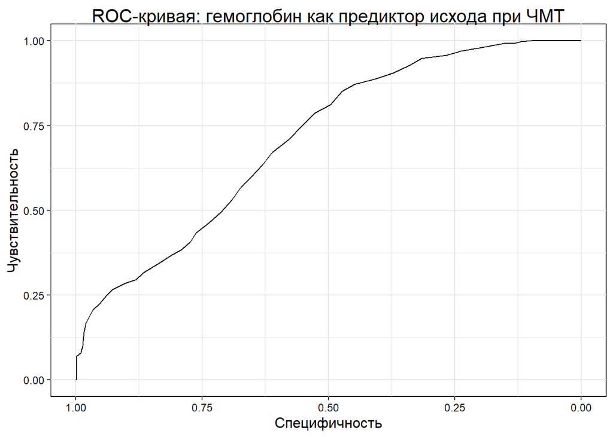

```r
roc(as.numeric(trauma$Death), trauma$Hb, ci = TRUE) %>%
  ggroc()+
  labs(
    title = 'ROC-кривая: гемоглобин как предиктор исхода при ЧМТ',
    x = 'Специфичность',
    y = 'Чувствительность'
  )
```

ROC-кривая выгнута в сторону верхнего левого угла, который соответствует 100% чувствительности и специфичности, что свидетельствует о возможности предсказания летального схода в течение 24 часов (после госпитализации) по причине получения черепно-мозговой травмы на основании уровня гемоглобина. Такая ROC-кривая согласуется с выводами, сделанными по таблице 3 с соотношением пациентов с анемией в разных группах исхода. Здесь также можно выделить два небольших пика, возможно соответствующих двум разных пороговым значениям уровня гемоглобина у мужчин и женщин, что скорее всего может влиять на точность теста при обобщении результатов на мужчин и женщин.

### **Анализ площади под ROC-кривой**

```r
roc(as.numeric(trauma$Death), trauma$Hb, ci = TRUE)
```

```
##
## Call:
## roc.default(response = as.numeric(trauma$Death), predictor = trauma$Hb,     ci = TRUE)
##
## Data: trauma$Hb in 605 controls (as.numeric(trauma$Death) 1) > 403 cases (as.numeric(trauma$Death) 2).
## Area under the curve: 0.7078
## 95% CI: 0.6763-0.7392 (DeLong)
```

Согласно результатам ROC-анализа, гемоглобин является статистически значимым предстказателем летального исхода в течение 24 часов (после госпитализации) по причине получения черепно-мозговой травмы. Площадь под ROC-кривой - значение AUC равно 0.71, 95% ДИ не включает значение 0.5 [0.68-0.74], соответствущее случайной диагностике исхода.

Направление связи controls (случаи НЕ наступления летального исхода) > cases (случаи наступления летального исхода), связывает состояние анемии и повышенного риска летального исхода, что мы предполагали из таблицы 3.

## **ROC-анализ предсказания летального исхода в течение 24 часов в зависимости от балла по шкале комы Глазго при поступлении**

### **Анализ ROC-кривой и площади под ROC-кривой**

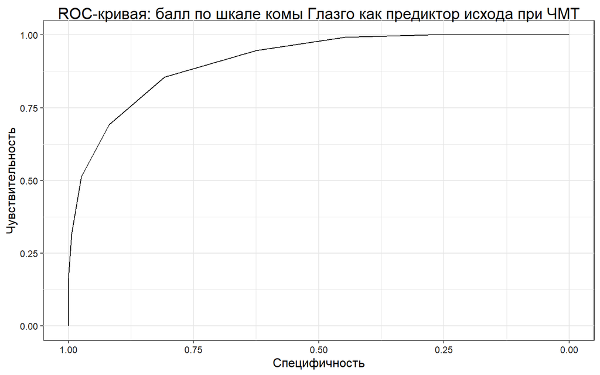

```r
rocGSC <- roc(response = as.numeric(trauma$Death), predictor = trauma$GSC, ci = TRUE)

rocGSC %>%
  ggroc()+
  labs(
    title = 'ROC-кривая: балл по шкале комы Глазго как предиктор исхода при ЧМТ',
    x = 'Специфичность',
    y = 'Чувствительность'
  )
```

```r
rocGSC
```

```
##
## Call:
## roc.default(response = as.numeric(trauma$Death), predictor = trauma$GSC,     ci = TRUE)
##
## Data: trauma$GSC in 615 controls (as.numeric(trauma$Death) 1) > 409 cases (as.numeric(trauma$Death) 2).
## Area under the curve: 0.9124
## 95% CI: 0.8959-0.9289 (DeLong)
```

Исходя из визуализации ROC-кривой и результатов ROC-анализа, балл по шкале комы Глазго является статистически значимым предсказателем летального исхода в течение 24 часов (после госпитализации) по причине получения черепно-мозговой травмы. Площадь под ROC-кривой - значение AUC равно 0.91, 95% ДИ не включает значение 0.5 [0.896-0.929], соответствущюее случайной диагностике исхода.

Направление связи controls (случаи НЕ наступления летального исхода) > cases (случаи наступления летального исхода), связывает баллы по шкале комы Глазго и вероятности выживания. Данный результат сопоставим с концепцией шкалы комы Глазго.

### **Анализ оптимального порогового значения для предсказания летального исхода в течение 24 часов по шкале комы Глазго**

```r
#Считаем оптимальное значение
rocGSC %>%
  coords(x = 'best', best.method = "closest.topleft") %>%

#визуализирем таблицу
  flextable() %>%
  theme_box() %>%
  bg(part = "header", bg = "aquamarine") %>%
  align(part = 'all', align = 'center') %>%
 set_header_labels(threshold = 'Оптимальное порогове значение', specificity = 'Специфичность', sensitivity = 'Чувствительность') %>%
  set_table_properties(layout = 'autofit', width = 0.8) %>%
  set_caption('Таблица 5 - Оптимальное пороговое значение для предсказания летального исхода по шкале комы Глазго, \nопределенное методом ближайшей точки к левому краю')
```

Таблица 5 - Оптимальное пороговое значение для предсказания летального исхода по шкале комы Глазго, определенное методом ближайшей точки к левому краю

| Оптимальное порогове значение | Специфичность | Чувствительность |
| --- | --- | --- |
| 7.5 | 0.8081301 | 0.8557457 |

Оптимальным для предсказания летального исхода в течение 24 часов (после госпитализации) по причине получения черепно-мозговой травмы на основании балла по шкале комы Глазго является пороговое значение равное 7.5. При таком пороговом значении (<7.5) тест будет обладает:

86% чувствительностью (т.е. в 86% случаев верно определяет случаи наступления летального исхода в течение 24 часов, в 14% случаев - получим ложноотрицательный результат)

81% специфичностью (т.е. 81% случаев НЕ наступления летального исхода в течение 24 часов мы определим верно, в 19% случаев - получим ложноположительный результат).

## **Анализ площади под ROC-кривой всех количественных данных**

```r
rocallnum <- trauma %>%
  select(Death, where(is.numeric)) %>%
  select(!c('id', 'Height', 'Weight', 'Heightm', 'Weightkg')) %>%
  pivot_longer(cols = !Death) %>%
  group_by(name) %>%
  summarise(AUC = roc(Death, value, ci = T)$ci[2] %>% round(3),
            AUC_LCL = roc(Death, value, ci = T)$ci[1] %>% round(3),
            AUC_UCL = roc(Death, value, ci = T)$ci[3] %>% round(3)) %>%
  arrange(AUC) %>%
  mutate(
    name = case_when(
      name == 'Heightm' ~ 'Рост',
      name == "Age" ~ 'Возраст',
      name == 'SBP' ~ 'САД',
      name == 'DBP' ~ 'ДАД',
      name == 'Weightkg' ~ 'Масса',
      name == 'Hb' ~ 'Уроверь гемоглобина',
      name == 'BMI' ~ 'ИМТ',
      name == 'GSC' ~ 'Балл по шкале комы Глазго ',
      name == 'FOUR' ~ 'Балл по шкале комы FOUR ',
      TRUE ~ name
    )
  ) %>%
  rename('Переменная' = name)

rocallnum %>%
  flextable() %>%
  theme_box() %>%
  bg(part = "header", bg = "aquamarine") %>%
  align(part = 'all', align = 'center') %>%
  set_table_properties(layout = 'autofit', width = 0.8) %>%
  set_caption('Таблица 6 - Значения AUC для всех количественных признаков')
```

Таблица 6 - Значения AUC для всех количественных признаков

| Переменная | AUC | AUC_LCL | AUC_UCL |
| --- | --- | --- | --- |
| ИМТ | 0.499 | 0.463 | 0.535 |
| Возраст | 0.527 | 0.491 | 0.563 |
| Уроверь гемоглобина | 0.708 | 0.676 | 0.739 |
| ДАД | 0.744 | 0.714 | 0.774 |
| САД | 0.786 | 0.759 | 0.814 |
| Балл по шкале комы Глазго | 0.912 | 0.896 | 0.929 |
| Балл по шкале комы FOUR | 0.934 | 0.920 | 0.948 |

Наименьшие площади под кривой (значения AUC), соответсвующие случайному оперделению признака 0.49 и 0.53, имеют переменные возраста и ИМТ, их 95% ДИ включают значение 0.5. Данные переменные имеют похожие статистики у двух групп исхода (то, что мы смотрели выше в таблице 2: среднее, медианы и др.) и не подходят для разделения групп и предсказания исхода.

Наилучшей предсказательной силой обладают баллы комы по шкале Глазго и FOUR, их значения AUC соответственно 0.91 и 0.93 с узкими 95% ДИ близкими к 1, что подтверждает их потенциальную состоятельность в оценке.

Остальные переменные (уровень гемоглобина, САД и ДАД) имеют промежуточные, но высокие значения AUC, 95% ДИ которых не включают 0.5, что показывает потенциально возможное использование данных параментров в оценке исхода.